# Kompakte Rundum-Einführung in R

Autor:in

Zugehörigkeiten

[Pawel R. Kulawiak](https://pawelkulawiak.github.io/)

[Universität zu Köln](https://www.uni-koeln.de/)

[Zentrum für Lehrer:innenbildung (ZfL)](https://zfl.uni-koeln.de/)

[Graduiertenschule für Lehrer:innenbildung (GSLB)](https://zfl.uni-koeln.de/graduiertenschule/die-graduiertenschule-auf-einen-blick/team)

Letzte Aktualisierung

22. April 2026

# Warum R?

## Transparenz und Reproduzierbarkeit der Analysen (Open Science mit R)

**Transparenz** und **Reproduzierbarkeit** sind zwei zentrale Aspekte der offenen Wissenschaftspraxis (Open Science). In diesem Sinne soll der gesamte Forschungsprozess (Planung, Durchführung, Analyse, usw.) transparent dokumentiert und diese Dokumentation öffentlich zugänglich gemacht werden. Dadurch werden alle Forschungsprozesse nachvollziehbar sowie reproduzierbar. Dies wird z.B. von der UNESCO empfohlen: [UNESCO Recommendation on Open Science](https://doi.org/10.54677/MNMH8546).

[video not shown]

Der analytische Teil des Forschungsprozesses (z.B. Datenaufbereitung und statistische Datenanalyse) soll ebenfalls transparent dokumentiert und zugänglich gemacht werden. [UNESCO Recommendation on Open Science](https://doi.org/10.54677/MNMH8546):

> “**Open research data** that include, among others, **digital and analogue data**, both **raw and processed**, and the accompanying metadata, as well as numerical scores, textual records, images and sounds, protocols, **analysis code and workflows** that can be **openly used**, **reused**, **retained** and **redistributed** by anyone, subject to acknowledgement. Open research data are available in a timely and user-friendly, human- and machine-readable and actionable format, in accordance with principles of good data governance and stewardship, notably the FAIR (Findable, Accessible, Interoperable, and Reusable) principles, supported by regular curation and maintenance.”

Die Programmiersprache R eignet sich hervorragend für eine transparente und reproduzierbare Datenanalyse im Sinne der offenen Wissenschaftspraxis. Der R-Code dokumentiert alle Analyseschritte – von der Datenaufbereitung bis zur statistischen Auswertung. Hier ein Beispiel zur Berechnung des Mittelwerts (inkl. Boxplot-Visualisierung):

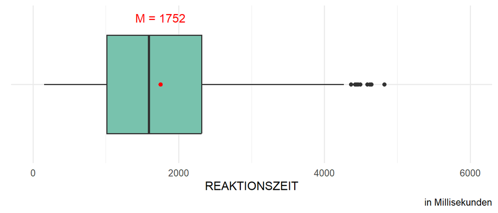

```r
library(tidyverse) # Umfassende Paketsammlung laden (Werkzeugkasten) https://tidyverse.tidyverse.org/
library(patchwork) # Weiteres Paket laden (für die Darstellung mehrerer Plots) https://patchwork.data-imaginist.com/

### Daten filtern
### Ausreißer ausschließen (Reaktionszeit ≥ 5000)

DATA_OHNE_AUSREISSER <-
  DATA %>%
  filter(REAKTIONSZEIT < 5000) # Kinder mit Reaktionszeit < 5000 beibehalten

### Boxplot mit Mittelwert

DATA_OHNE_AUSREISSER %>%
  ggplot(aes(x = REAKTIONSZEIT, y = "")) +
  geom_boxplot(fill = "#78C2AD") +
  stat_summary(fun = mean, geom = "point", color = "red") +
  stat_summary(fun = mean, geom = "text", aes(label = paste0("M = ", round(..x..))), color = "red", vjust = -7) +
  xlim(c(0, 6000)) +
  ylab(NULL) +
  labs(caption = "in Millisekunden") +
  theme_minimal(base_size = 12)
```

In diesem Beispiel ist dokumentiert, dass die Berechnung des Mittelwertes ohne spezifische Ausreißer erfolgte. Anhand des offen zugänglichen R-Codes ist der Analyseprozess nachvollziehbar und kann somit kritisch überprüft und sogar wiederholt (also reproduziert) werden, sofern auch der dazugehörige Datensatz offen zugänglich ist. Die Analysen können dann sogar abgewandelt und erweitert werden, sofern kritische Wissenschaftler:innen z.B. den Ausschluss von Ausreißern hinterfragen und folglich die Ergebnisse mit und ohne Berücksichtigung der Ausreißer abgleichen möchten:

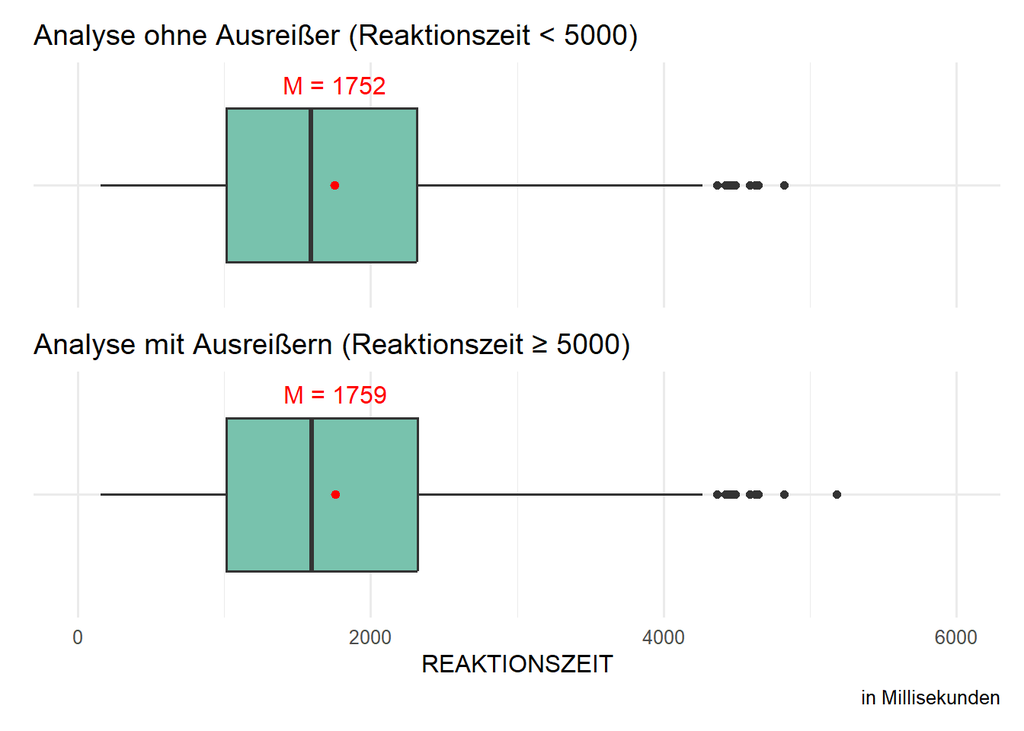

```r
### Daten filtern
### Ausreißer ausschließen (Reaktionszeit ≥ 5000)

DATA_OHNE_AUSREISSER <-
  DATA %>%
  filter(REAKTIONSZEIT < 5000) # Kinder mit Reaktionszeit < 5000 beibehalten

### Analyse ohne Ausreißer (Reaktionszeit < 5000)

BOXPLOT_1 <-
  DATA_OHNE_AUSREISSER %>%
  ggplot(aes(x = REAKTIONSZEIT, y = "")) +
  geom_boxplot(fill = "#78C2AD") +
  stat_summary(fun = mean, geom = "point", color = "red") +
  stat_summary(fun = mean, geom = "text", aes(label = paste0("M = ", round(..x..))), color = "red", vjust = -5) +
  xlim(c(0, 6000)) +
  ylab(NULL) +
  #labs(caption = "in Millisekunden") +
  ggtitle("Analyse ohne Ausreißer (Reaktionszeit < 5000)") +
  theme_minimal(base_size = 12)

### Analyse mit Ausreißern (Reaktionszeit ≥ 5000)

BOXPLOT_2 <-
  DATA %>%
  ggplot(aes(x = REAKTIONSZEIT, y = "")) +
  geom_boxplot(fill = "#78C2AD") +
  stat_summary(fun = mean, geom = "point", color = "red") +
  stat_summary(fun = mean, geom = "text", aes(label = paste0("M = ", round(..x..))), color = "red", vjust = -5) +
  xlim(c(0, 6000)) +
  ylab(NULL) +
  labs(caption = "in Millisekunden") +
  ggtitle("Analyse mit Ausreißern (Reaktionszeit ≥ 5000)") +
  theme_minimal(base_size = 12)

BOXPLOT_1 / BOXPLOT_2 + plot_layout(axes = "collect") # Beide Boxplots untereinander anzeigen
```

Gelebte offenen Wissenschaftspraxis (Open Science) bedeutet nun, dass der R-Code und die dazugehörigen Daten frei zugänglich gemacht werden. Hierfür können entsprechende Open-Science-Portale genutzt werden, wie z.B. [OSF](https://osf.io/), [Figshare](https://figshare.com/), [Zenodo](https://zenodo.org/) oder [GitHub](https://github.com/). Selbstverständlich ist hierbei darauf zu achten, dass die veröffentlichten Daten [keine personenbezogene Daten im Sinne der DSGVO](https://www.bfdi.bund.de/DE/Buerger/Inhalte/Allgemein/Datenschutz/GrundlagenDatenschutzrecht.html) beinhalten. Nachfolgend sehen wir einige Beispiele aus der Forschungspraxis mit Veröffentlichung der Daten und des R-Codes. In den entsprechenden Papern erfolgt stets ein Verweis auf die Hinterlegung der Daten und des R-Codes innerhalb eines Open-Science-Portals.

**TippBeispiel 1**

Kashikar, L., Soemers, L., Lüke, T., & Grosche, M. (2024). Influence of the ‘Learning Disability’ label on teachers’ performance expectations—a matter of attitudes towards inclusion? In Journal of Research in Special Educational Needs (Vol. 24, Issue 3, pp. 696–712).

- https://doi.org/10.1111/1471-3802.12664 (Paper)
- https://osf.io/k8ejv/ (Übersicht)
- https://osf.io/k8ejv/files/osfstorage (Daten und R-Code)

**TippBeispiel 2**

Young, E. S., Frankenhuis, W. E., DelPriore, D. J., & Ellis, B. J. (2022). Hidden talents in context: Cognitive performance with abstract versus ecological stimuli among adversity‐exposed youth. In Child Development (Vol. 93, Issue 5, pp. 1493–1510).

- https://doi.org/10.1111/cdev.13766 (Paper)
- https://github.com/ethan-young/hidden-talents-multiverse (Daten und R-Code)

**TippBeispiel 3**

Heyard, R., Ott, M., Salanti, G., & Egger, M. (2022). Rethinking the Funding Line at the Swiss National Science Foundation: Bayesian Ranking and Lottery. In Statistics and Public Policy (Vol. 9, Issue 1, pp. 110–121).

- https://doi.org/10.1080/2330443X.2022.2086190 (Paper)
- https://doi.org/10.5281/zenodo.4531159 (Daten)
- https://snsf-data.github.io/ERpaper-online-supplement/ (R-Code als Website)
- https://github.com/snsf-data/ERforResearch (R-Code bei GitHub)

**TippBeispiel 4**

Kulawiak, P. R., Poltz, N., Bosch, J., & Dreesmann, M. (2025). Understanding teachers’ perspectives on students with epilepsy in Germany: A survey examining knowledge, experience, and affective, cognitive, and behavioral attitudes to inform teacher training. In Epilepsy & Behavior (Vol. 163, p. 110157).

- https://doi.org/10.1016/j.yebeh.2024.110157 (Paper)
- https://doi.org/10.5281/zenodo.14210541 (Daten und R-Code)
- https://pawelkulawiak.github.io/supplepi/ (Daten und R-Code als Website)
- https://github.com/PawelKulawiak/supplepi (Daten und R-Code bei GitHub)

## Ästhetische, adaptive und flexible Output-Formate (SPSS vs. R)

Mit R können die Ergebnisse (Output der Analysen), seien es Tabellen oder Grafiken, sehr effektiv angepasst und gestaltet werden, wodurch eine sehr ästhetische Berichterstattung in unterschiedlichen Formaten möglich ist (Word, PDF, PowerPoint, HTML, uvm.). Unterschiedliche Output-Formate lassen sich mit dem [Quarto-Modul](https://quarto.org/) erzeugen, welches in [RStudio](https://posit.co/download/rstudio-desktop/) integriert ist.

SPSS-Output-Formate sind hingegen oft unübersichtlich und umständlich anzupassen. Hier erfolgt beispielhaft die Darstellung einer SPSS-Korrelationstabelle:

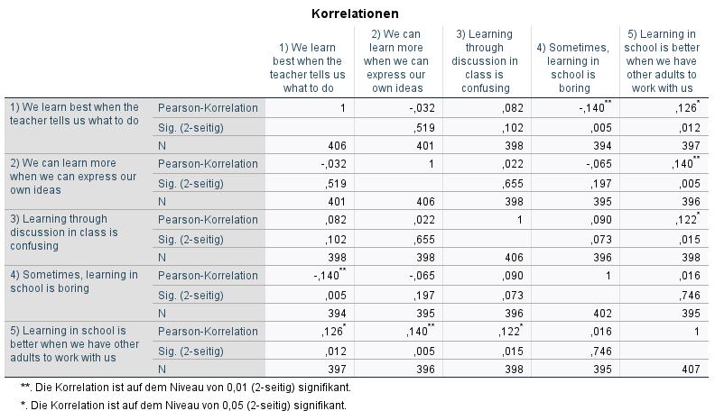

**TippDatenquelle für Korrelationstabelle**

Díez-Palomar J, García-Carrión R, Hargreaves L, Vieites M (2020) Transforming students’ attitudes towards learning through the use of successful educational actions. PLoS ONE 15(10): e0240292.

- https://doi.org/10.1371/journal.pone.0240292 (Paper)
- https://doi.org/10.1371/journal.pone.0240292.s002 (SPSS-Datensatz pone.0240292.s002.sav)

Der SPSS-Output muss nach Word oder Excel kopiert und dort anschließend weiterverarbeitet werden, sofern z.B. die Darstellung der Korrelationstabelle [im APA-Format](https://apastyle.apa.org/style-grammar-guidelines/tables-figures/sample-tables) erwünscht ist. Dieses (umständliche) Vorgehen sehen wir im nachfolgendem Video.

[video not shown]

In R können wir hingegen sehr effizient eine adäquate Korrelationstabelle (in Anlehnung an das APA-Format) sowie eine Visualisierung der Korrelationstabelle erzeugen:

```r
library(haven) # Paket für SPSS-Datenimport (SAV) https://haven.tidyverse.org/
library(sjPlot) # Paket für Korrelationstabelle https://strengejacke.github.io/sjPlot/

DATA <-
  read_sav("pone.0240292.s002.sav") # SPSS-Datenimport

DATA %>%
  select(Q1, Q2, Q3, Q4, Q5) %>% # Variablen auswählen
  tab_corr(na.deletion = "pairwise", triangle = "lower") # Korrelationstabelle (in Anlehnung an das APA-Format)
```

|  | 1) We learn best when the teacher tells us what to do | 2) We can learn more when we can express our own ideas | 3) Learning through discussion in class is confusing | 4) Sometimes, learning in school is boring | 5) Learning in school is better when we have other adults to work with us |
| --- | --- | --- | --- | --- | --- |
| 1) We learn best when the teacher tells us what to do |  |  |  |  |  |
| 2) We can learn more when we can express our own ideas | -0.032 |  |  |  |  |
| 3) Learning through discussion in class is confusing | 0.082 | 0.022 |  |  |  |
| 4) Sometimes, learning in school is boring | -0.140** | -0.065 | 0.090 |  |  |
| 5) Learning in school is better when we have other adults to work with us | 0.126* | 0.140** | 0.122* | 0.016 |  |
| Computed correlation used pearson-method with pairwise-deletion. |  |  |  |  |  |

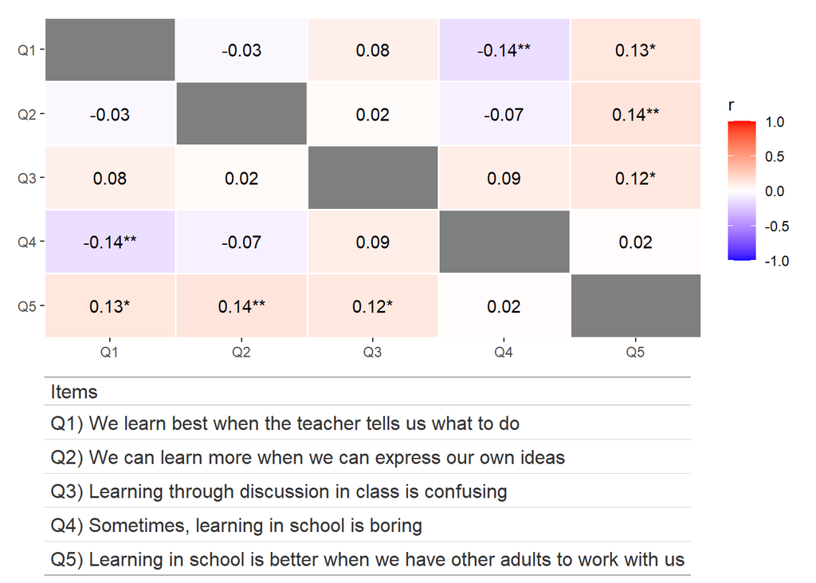

```r
library(correlation) # Pakete für visuelle Korrelationstabelle https://easystats.github.io/correlation/
library(see) # Pakete für visuelle Korrelationstabelle https://easystats.github.io/see/
library(gt) # Paket für schöne Tabellen https://gt.rstudio.com/

### Visuelle Korrelationstabelle

COR_PLOT <-
  DATA %>%
  select(Q1, Q2, Q3, Q4, Q5) %>% # Variablen auswählen
  correlation(p_adjust = "none") %>%
  summary(redundant = TRUE) %>%
  plot() +
  scale_fill_gradient2(low = "blue", mid = "white", high = "red", midpoint = 0, limits = c(-1, 1)) +
  ggtitle(NULL)

### Tabelle mit Hinweisen (Items)

TAB <-
  rbind(
  paste0("Q", attr(DATA$Q1, "label")),
  paste0("Q", attr(DATA$Q2, "label")),
  paste0("Q", attr(DATA$Q3, "label")),
  paste0("Q", attr(DATA$Q4, "label")),
  paste0("Q", attr(DATA$Q5, "label"))
  ) %>%
  tibble() %>%
  rename(Items = ".") %>%
  gt() %>%
  cols_align(align = "left") %>%
  tab_options(table.align = "left")

COR_PLOT / TAB + plot_layout(heights = c(8, 4)) # Plot und Tabelle untereinander anzeigen
```

## SPSS-Syntax vs. R-Code

Zu guter Letzt möchte ich SPSS-Syntax und R-Code beispielhaft gegenüberstellen, um zu demonstrieren, dass R-Code relativ elegant, prägnant und gut leserbar ist.

#### SPSS-Syntax

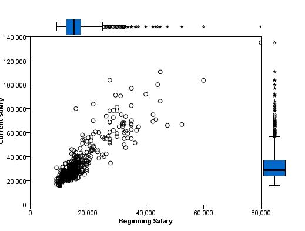

Quelle: https://www.ibm.com/docs/en/spss-statistics/29.0.0?topic=mgeg-scatterplot-border-boxplots-gpl

```html
BEGIN GPL
  SOURCE: s=userSource(id("graphdataset"))
  DATA: salary = col(source(s), name("salary"))
  DATA: salbegin = col(source(s), name("salbegin"))
  GRAPH: begin(origin(5%, 10%), scale(85%, 85%))
  GUIDE: axis(dim(1), label("Beginning Salary"))
  GUIDE: axis(dim(2), label("Current Salary"))
  ELEMENT: point(position(salbegin*salary))
  GRAPH: end()
  GRAPH: begin(origin(5%, 0%), scale(85%, 10%))
  COORD: rect(dim(1))
  GUIDE: axis(dim(1), ticks(null()))
  ELEMENT: schema(position(bin.quantile.letter(salbegin)), size(size."80%"))
  GRAPH: end()
  GRAPH: begin(origin(90%, 10%), scale(10%, 85%))
  COORD: transpose(rect(dim(1)))
  GUIDE: axis(dim(1), ticks(null()))
  ELEMENT: schema(position(bin.quantile.letter(salary)), size(size."80%"))
  GRAPH: end()
END GPL.
```

#### R-Code

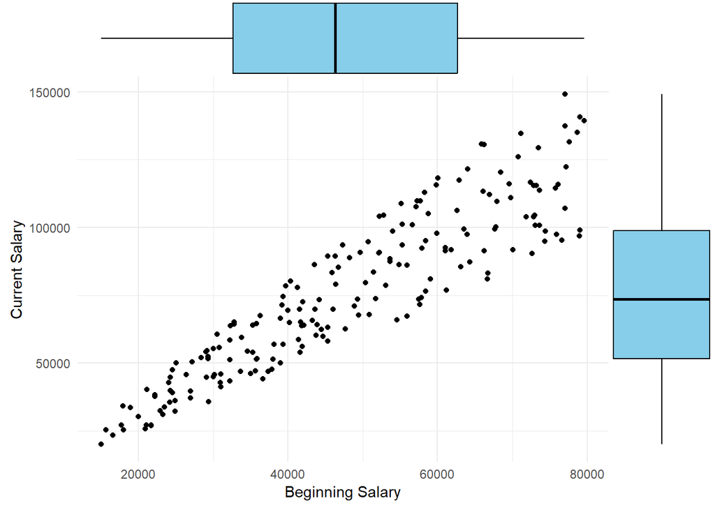

```r
library(ggExtra) # Paket für marginal boxplots

PLOT <- # scatter plot (ohne marginal boxplots)
  DATA %>%
  ggplot(aes(x = Beginning_Salary, y = Current_Salary)) +
  geom_point() +
  labs(x = "Beginning Salary", y = "Current Salary") +
  theme_minimal()

PLOT %>%
  ggMarginal(type = "boxplot",
             margins = "both",
             size = 5,
             fill = "skyblue") # add marginal boxplots
```

## Interaktive Output-Formate (R-Shiny-Apps)

Mit R können die Ergebnisse sehr effektiv angepasst und gestaltet werden. Mit dem [Quarto-Modul](https://quarto.org/), welches in [RStudio](https://posit.co/download/rstudio-desktop/) integriert ist, können wir zudem unterschiedliche Formate erzeugen (Word, PDF, PowerPoint, HTML, uvm.). Außerdem können sogar interaktive Output-Formate erstellt werden, also interaktive Ergebnisdarstellungen mit interaktiver Benutzeroberfläche (sogenannte [R-Shiny-Apps](https://shiny.posit.co/)). Eine R-Shiny-App kann lokal auf dem Rechner gestartet oder als Online-Anwendung genutzt werden. Mit der nachfolgenden R-Shiny-App kann man z.B. die Wortschatz-Entwicklung für spezifische Kinder anzeigen lassen.

**TippR-Shiny-App mit fiktiven Daten (Wortschatz-Entwicklung)**

- https://kulawiak.shinyapps.io/demoapp/

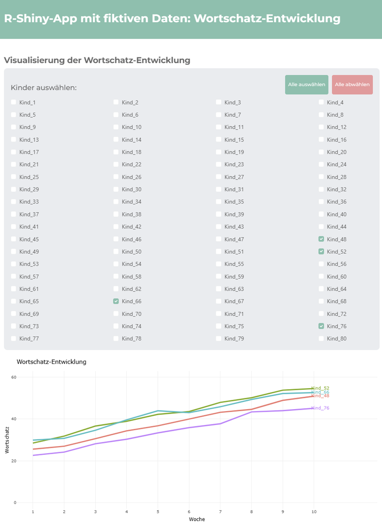

## Vielfalt der Möglichkeiten (Pakete)

Mit R kann man (fast) alles machen und innovative/neuartige Analyseansätze sind in der Regel zeitnah in R verfügbar. Somit ist R eine Art [Schweizer Taschenmesser](https://de.wikipedia.org/wiki/Schweizer_Taschenmesser). Die Vielfalt der Möglichkeiten ist über sogenannte [Pakete](https://r-pkgs.org/introduction.html) möglich. Spezifische Verfahren und Analyseansätze werden in solchen Paketen zur Verfügung gestellt, wobei jede Person Pakete entwickeln und veröffentlichen kann. R ist daher ein „Community Project“ und jede Person kann dazu beitragen.

Nachfolgend wird die Funktionalität von einigen Paketen exemplarisch aufgezeigt.

**TippNetzwerkanalyse: visNetwork & igraph**

- https://datastorm-open.github.io/visNetwork/
- https://r.igraph.org/

[video not shown]

**TippText Mining: tidytext**

- https://juliasilge.github.io/tidytext/
- https://www.tidytextmining.com/

[video not shown]

**TippItem Response Theory (z.B. Rasch): TAM**

- https://www.edmeasurementsurveys.com/TAM/Tutorials/
- https://www.edmeasurementsurveys.com/IRT/

[video not shown]

**TippGeospatial Data Analysis: sf**

- https://r-spatial.github.io/sf/
- https://r.geocompx.org/

[video not shown]

[figure not shown]

Schweizer Taschenmesser: SPSS (links) und R (rechts)

## Open Source, Community & Support

> „R is free software and comes with ABSOLUTELY NO WARRANTY. You are welcome to redistribute it under certain conditions. R is a collaborative project with many contributors.“

R ist nicht nur kostenlos und frei verfügbar, sondern verfügt auch über eine große, aktive und hilfsbereite Community sowie umfangreiche Dokumentation, Tutorials und kostenlose Lernressourcen.

Weitere Infos auf der R-Startseite: https://www.r-project.org/

Zudem gehört R zu den beliebtesten Programmiersprachen weltweit und belegt zurzeit (April 2025) Platz 6 gemäß PYPL-Index [(PopularitY of Programming Language)](https://pypl.github.io/PYPL.html). Es gibt aber auch weitere frei verfügbare Programmiersprachen für den vielfältigen Einsatz im Bereich der statistischen Datenanalyse, z.B. [Python](https://www.python.org/) und [Julia](https://julialang.org/).

PYPL PopularitY of Programming Language Index (April 2025): https://pypl.github.io/PYPL.html

| Rank | Change | Language | Share | 1-year trend |
| --- | --- | --- | --- | --- |
| 1 |  | Python | 30.27 % | +1.4 % |
| 2 |  | Java | 15.04 % | -0.6 % |
| 3 |  | JavaScript | 7.93 % | -0.7 % |
| 4 |  | C/C++ | 6.99 % | +0.6 % |
| 5 |  | C# | 6.2 % | -0.6 % |
| **6** |  | **R** | **4.59 %** | **+0.0 %** |
| 7 |  | PHP | 3.74 % | -0.8 % |
| 8 |  | Rust | 3.14 % | +0.5 % |
| 9 |  | TypeScript | 2.79 % | -0.1 % |
| 10 |  | Objective-C | 2.72 % | +0.3 % |

# Installation: R und Rstudio

- https://posit.co/download/rstudio-desktop/

**Wichtig**

- Erklären was posit ist
- R und Rstudio erklären
- **In Zukunft wird Rstudio von Positron abgelöst**: https://positron.posit.co/

Ismay, Kim, & Valdivia (2025): Analogy of difference between R and RStudio (https://moderndive.com/v2/getting-started.html)

[figure not shown]

Ismay, Kim, & Valdivia (2025): Icons of R versus RStudio on your computer (https://moderndive.com/v2/getting-started.html)

# Wir starten RStudio

**Wichtig**

- Script öffnen

## Arithmetik und Objekte

| **Operator** | **Beschreibung** | **Beispiel** | **Ergebnis** |
| --- | --- | --- | --- |
| `+` | Addition | `5 + 3` | `8` |
| `-` | Subtraktion | `10 – 5` | `5` |
| `*` | Multiplikation | `3 * 5` | `15` |
| `/` | Division | `10 / 2` | `5` |
| `^` | Exponentiation | `2^3` | `8` |

> Body mass index (BMI) is a value derived from the mass (weight) and height of a person. The BMI is defined as the body mass divided by the square of the body height, and is expressed in units of kg/m<sup>2</sup>, resulting from mass in kilograms (kg) and height in metres (m). https://en.wikipedia.org/wiki/Body_mass_index

> BMI = kg/m<sup>2</sup>

**Wichtig**

Objekte anlegen und BMI berechnen:

- Augenfarbe (AUGENFARBE)
- Gewicht in kg (GEWICHT_IN_KG)
- Größe in m (GROESSE_IN_M)
- BMI

```r
AUGENFARBE <- "Blaugrau"
GEWICHT_IN_KG <- 84
GROESSE_IN_M <- 1.80
# BMI-Berechnung
GEWICHT_IN_KG / GROESSE_IN_M^2
```

```
[1] 25.92593
```

```r
BMI <- GEWICHT_IN_KG / GROESSE_IN_M^2 # BMI-Berechnung
BMI
```

```
[1] 25.92593
```

```r
BMI * AUGENFARBE
# Error in BMI * AUGENFARBE : non-numeric argument to binary operator
```

## Vektoren und Datensätze

```r
NAME <-
  c("Susi", "Ali", "Klaus")

AUGENFARBE <-
  c("Blaugrau", "Braun", "Grün")

GEWICHT_IN_KG <-
  c(84, 65, 72)

GROESSE_IN_M <-
  c(1.80, 1.65, 1.75)

DATA <-
  data.frame(NAME, AUGENFARBE, GEWICHT_IN_KG, GROESSE_IN_M)

DATA <-
  data.frame(NAME,
             AUGENFARBE,
             GEWICHT_IN_KG,
             GROESSE_IN_M)

DATA
```

```
   NAME AUGENFARBE GEWICHT_IN_KG GROESSE_IN_M
1  Susi   Blaugrau            84         1.80
2   Ali      Braun            65         1.65
3 Klaus       Grün            72         1.75
```

**Wichtig**Übung**

**Ergänzen Sie den Datensatz um 2 Personen und erstellen Sie eine zusätzliche Variable (z.B. Anzahl der Haustiere). Speichern Sie den Datensatz als Objekt `DATA`.**

**Wichtig**Lösung**

```r
NAME <-
  c("Susi", "Ali", "Klaus", "Oleg", "Rudi")

AUGENFARBE <-
  c("Blaugrau", "Braun", "Grün", "Grün", "Grau")

GEWICHT_IN_KG <-
  c(84, 65, 72, 66, 70)

GROESSE_IN_M <-
  c(1.80, 1.65, 1.75, 1.63, 2.10)

ANZAHL_HAUSTIERE <-
  c(2, 0, 0, 1, 0)

DATA <-
  data.frame(NAME, AUGENFARBE, GEWICHT_IN_KG, GROESSE_IN_M, ANZAHL_HAUSTIERE)

DATA <-
  data.frame(NAME,
             AUGENFARBE,
             GEWICHT_IN_KG,
             GROESSE_IN_M,
             ANZAHL_HAUSTIERE)

DATA
```

```
   NAME AUGENFARBE GEWICHT_IN_KG GROESSE_IN_M ANZAHL_HAUSTIERE
1  Susi   Blaugrau            84         1.80                2
2   Ali      Braun            65         1.65                0
3 Klaus       Grün            72         1.75                0
4  Oleg       Grün            66         1.63                1
5  Rudi       Grau            70         2.10                0
```

```r
DATA$NAME
```

```
[1] "Susi"  "Ali"   "Klaus" "Oleg"  "Rudi"
```

```r
DATA$BMI <-
  DATA$GEWICHT_IN_KG / DATA$GROESSE_IN_M^2 # BMI-Berechnung

DATA
```

```
   NAME AUGENFARBE GEWICHT_IN_KG GROESSE_IN_M ANZAHL_HAUSTIERE      BMI
1  Susi   Blaugrau            84         1.80                2 25.92593
2   Ali      Braun            65         1.65                0 23.87511
3 Klaus       Grün            72         1.75                0 23.51020
4  Oleg       Grün            66         1.63                1 24.84098
5  Rudi       Grau            70         2.10                0 15.87302
```

```r
DATA[3, 2] # 3. Person, 2. Variable
```

```
[1] "Grün"
```

```r
DATA[3, "GEWICHT_IN_KG"]
```

```
[1] 72
```

```r
DATA[c(2,4), c("NAME", "GEWICHT_IN_KG")]
```

```
  NAME GEWICHT_IN_KG
2  Ali            65
4 Oleg            66
```

## Pakete installieren und laden (Beispiel tidyverse, writexl & gt)

Das Tidyverse ist eine Sammlung von R-Paketen für das Datenmanagement und die Analyse von Daten. Das Tidyverse ist heutzutage zunehmend der Standard in der R-Welt: https://www.tidyverse.org/

[video not shown]

Mit der Installation sind u.a. folgende Pakete verfügbar:

- **ggplot2**: Erstellt schöne Grafiken und Diagramme
- **dplyr**: Vereinfacht die Datenmanipulation (filtern, sortieren, zusammenfassen)
- **tidyr**: Hilft beim Aufräumen und Umstrukturieren von Daten
- **readr**: Importiert Textdateien (wie CSV)
- **tibble**: Eine moderne Version des Dataframes
- **stringr**: Vereinfacht die Arbeit mit Texten
- **forcats**: Hilft bei der Arbeit mit kategorialen Variablen
- **lubridate**: Vereinfacht die Arbeit mit Datums- und Zeitwerten
- **readxl**: Ermöglicht den Import von Excel-Dateien
- **haven**: Importiert Daten aus SPSS, Stata und SAS

Das tidyverse enthält aber leider kein Paket für den Datenexport im Excel-Format. Daher installieren wir auch das Paket **writexl**: https://docs.ropensci.org/writexl/

**gt** ist ein Paket für die Gestaltung von Tabellen: https://gt.rstudio.com/

```r
# Ein Paket muss nach der Installation mit dem library Befehl aktiviert werden (einmalig bei jeder R-Sitzung):

library(writexl)
library(gt)

# Nach der Installation des tidyverse:
# Immer wenn wir mit R arbeiten, müssen die Pakete des tidyverse aktiviert werden (einmalig bei jeder R-Sitzung).
# Die allermeisten Pakete des tidyverse werden somit verfügbar gemacht.
# Einzelne Pakete des tidyverse müssen aber separat aktiviert werden (z.B. haven & readxl).

library(tidyverse)
library(haven)
library(readxl)
```

# Daten-Export und Daten-Import ins Arbeitsverzeichnis

## Export (Excel)

**Wichtig**

Skript in einem Arbeitsordner (Projektordner) speichern

```r
library(writexl)
write_xlsx(DATA, path = "test.xlsx")
write_xlsx(DATA, path = "C:\\Users\\Graduiertenschule\\Desktop\\test.xlsx")
write_xlsx(DATA, "test.xlsx")
writexl::write_xlsx(DATA, "test.xlsx") # Double Colon Operator: paket::funktion()
```

```r
getwd() # Get Working Directory
```

```
[1] "C:/Users/Graduiertenschule/Dropbox/GSLB/R Workshop"
```

```r
# setwd("C:\\Users\\Graduiertenschule\\Desktop") # Set Working Directory
```

[figure not shown]

Set and Get Working Directory

## Import (Excel)

**Wichtig**

Skript in einem Arbeitsordner (Projektordner) speichern

```r
library(readxl) # https://readxl.tidyverse.org/
read_xlsx("test.xlsx")
```

```
# A tibble: 5 × 6
  NAME  AUGENFARBE GEWICHT_IN_KG GROESSE_IN_M ANZAHL_HAUSTIERE   BMI
  <chr> <chr>              <dbl>        <dbl>            <dbl> <dbl>
1 Susi  Blaugrau              84         1.8                 2  25.9
2 Ali   Braun                 65         1.65                0  23.9
3 Klaus Grün                  72         1.75                0  23.5
4 Oleg  Grün                  66         1.63                1  24.8
5 Rudi  Grau                  70         2.1                 0  15.9
```

```r
NEW_DATA <- read_xlsx("test.xlsx")
```

## Import (SPSS)

**TippDatenquelle (SPSS)**

Díez-Palomar J, García-Carrión R, Hargreaves L, Vieites M (2020) Transforming students’ attitudes towards learning through the use of successful educational actions. PLoS ONE 15(10): e0240292.

- https://doi.org/10.1371/journal.pone.0240292 (Paper)
- https://doi.org/10.1371/journal.pone.0240292.s002 (SPSS-Datensatz pone.0240292.s002.sav)

```r
library(tidyverse) # https://tidyverse.tidyverse.org/
library(haven) # https://haven.tidyverse.org/
library(gt) # https://gt.rstudio.com/

DATA_SPSS <- read_sav("pone.0240292.s002.sav")
DATA_SPSS <- read_sav("https://doi.org/10.1371/journal.pone.0240292.s002")

DATA_SPSS$Q1
```

```
<labelled<double>[418]>: 1) We learn best when the teacher tells us what to do
  [1]  2  1  1  1  3  2  1  3  2  4  2  1  1  1  2  1  1  2  1  1  1  2  1  3  1
 [26]  2  3  3  1  4  1  2  2  2  4  2  1  2  1  4  2  1  1  3  2  2  5  2  2  1
 [51]  3  1  2  2  1  1  1  1  3  3  2  2  2  1  2  1  1  2  1  1  2  2  2  3  3
 [76]  1  2  2  1  5  2  3  1  2  1  2  3  4  2  1  4  1  1  1  5  1  3  2  2  1
[101]  2  1  4  2  2  2  1  5  2 NA  3  3  1  3  2  1  2  2  3  2  1  2  1  1  1
[126]  1  1  1  2  2  1  1  1  2  2  1  1  1  1  1  1  1  1  1  1 NA  2  3  1  1
[151]  2  2  1  2  1  1  1  1  1  1 NA  1  3  1  5  1  3  1  5  2  2  2  1  2  1
[176]  3  1  2  1  1  1  2 NA  1  2  1  1  1  1  1  3  1  1  5  1  1  1  3  1  1
[201]  1  2  2  1  3  1  3  1  1  1  4  1  1  3  2  3  1  1  1  1  3  1  5  3  1
[226]  1  5  1  4  2  2  4  2  5  3  1  5  3  3  3  5  4  3  3  2  2  2  1  4  5
[251] NA  1  1  1  1  1  1  1  1  1  1  1  1  1  1  1  2  1  1  1  1  1  1  2  1
[276]  1  1  1  1  1  1  1  2  1  1  1  2  1  1  1  1  1  1  1  1  1  1  1  1  1
[301]  1  1  1  1  1  3  1  1  1  1  1  1  1  1  1  1  1  1  1  1  1  1  1  2  1
[326]  1  1  1  1  1  1  1  1  1  1  2  1  1  1  1  4  1  2  1  1  1  1  1  1  5
[351]  1  1  1  1  2  1  1  1  5  1  1  1  1 NA  1  1  1  1  1  3  1  1  1  2  1
[376]  1  1  1  1  1  1  4  1  1  1  1  1  1  1  1  1  1  1  1  1  1  1  1  1  1
[401]  2 NA  5 NA NA  3 NA  1  3 NA  4  2  1  4  1  1 NA  5

Labels:
 value             label
     0         Undefined
     1    Strongly agree
     2    Agree a little
     3          Not sure
     4 Disagree a little
     5 Strongly disagree
```

```r
DATA_SPSS %>%
  mutate(Q1 = Q1 %>% as_factor()) %>%
  count(Q1)
```

```
# A tibble: 6 × 2
  Q1                    n
  <fct>             <int>
1 Strongly agree      252
2 Agree a little       81
3 Not sure             40
4 Disagree a little    16
5 Strongly disagree    17
6 <NA>                 12
```

```r
DATA_SPSS %>%
  mutate(Q1 = Q1 %>% as_factor()) %>%
  count(Q1) %>%
  gt() %>%
  tab_options(table.align = "left")
```

| 1) We learn best when the teacher tells us what to do | n |
| --- | --- |
| Strongly agree | 252 |
| Agree a little | 81 |
| Not sure | 40 |
| Disagree a little | 16 |
| Strongly disagree | 17 |
| NA | 12 |

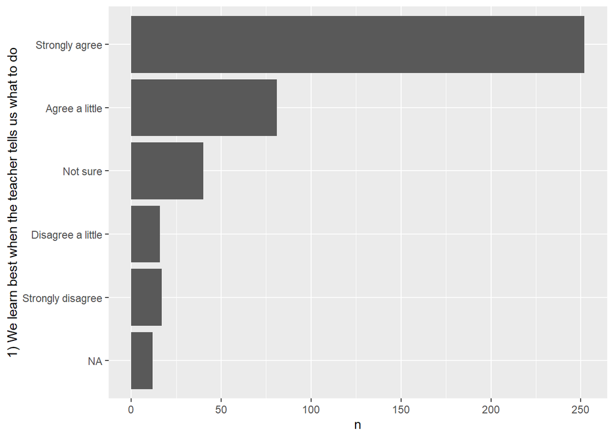

```r
DATA_SPSS %>%
  mutate(Q1 = Q1 %>% as_factor()) %>%
  count(Q1) %>%
  ggplot(aes(x = n, y = Q1)) +
  geom_col() +
  labs(y = attr(DATA_SPSS$Q1, "label")) +
  scale_y_discrete(limits = rev)
```

**NA: Not Available / Missing Values**

# Univariate deskriptive Statistik

**TippDatenquelle**

Imuta K, Scarf D, Pharo H, Hayne H (2013) Drawing a Close to the Use of Human Figure Drawings as a Projective Measure of Intelligence. PLoS ONE 8(3): e58991.

- https://doi.org/10.1371/journal.pone.0058991 (Paper)
- https://doi.org/10.1371/journal.pone.0058991.s001 (Daten im Word-Format)
- https://github.com/PawelKulawiak/rworkshop/blob/main/DATA_doi_10.1371_journal.pone.0058991.xlsx (Daten im Excel-Format)
- https://github.com/PawelKulawiak/rworkshop/raw/refs/heads/main/DATA_doi_10.1371_journal.pone.0058991.xlsx (Direkter Download: Daten im Excel-Format)

Variablen:

- DAP_IQ: [Draw-A-Person Intellectual Ability Test](https://en.wikipedia.org/wiki/Draw-a-Person_test) ([Mann-Zeichen-Test](https://www.testzentrale.de/shop/der-mann-zeichen-test.html))
- WPPSI: [Wechsler Preschool and Primary Scale of Intelligence](https://de.wikipedia.org/wiki/Wechsler_Preschool_and_Primary_Scale_of_Intelligence)

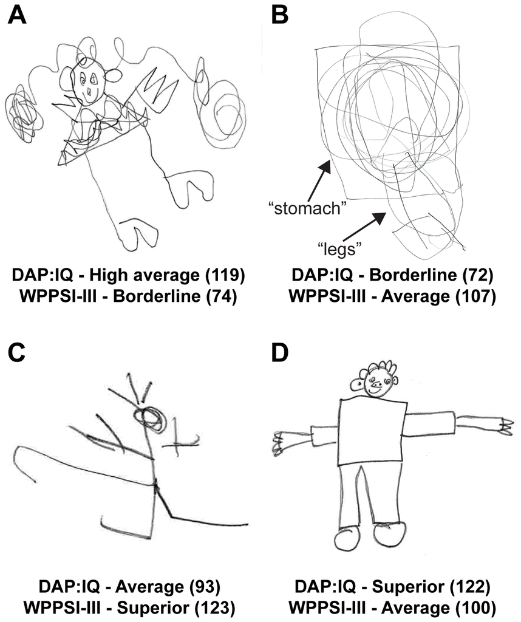

[figure not shown]

[figure not shown]

```r
library(readxl)
DATA <- read_xlsx("DATA_doi_10.1371_journal.pone.0058991.xlsx")
```

## Mittelwert, Standardabweichung und Co.

```r
DATA$DAP_IQ
```

```
  [1]  67  72  73  79  79  83  83  84  88  89  89  92  92  93  93  93  93  93
 [19]  93  96  96  96  96  97  97  97  97  97  97  97  97  97  97  98  98  98
 [37] 100 101 101 102 103 103 106 106 106 106 106 107 108 108 108 108 109 110
 [55] 110 110 110 111 111 111 111 111 111 111 113 114 114 115 115 116 116 116
 [73] 116 117 119 119 119 119 119 119 120 121 121 121 121 121 121 122 122 122
 [91] 122 123 123 124 124 125 135 139 140 142
```

```r
mean(DATA$DAP_IQ, na.rm = TRUE) # NA remove: remove missing values (NA: Not Available / Missing Values)
```

```
[1] 106.56
```

```r
mean(DATA$DAP_IQ, na.rm = T, trim = 0.1) # trim: Getrimmter Mittelwert
```

```
[1] 107.025
```

```r
round(mean(DATA$DAP_IQ, na.rm = T, trim = 0.1))
```

```
[1] 107
```

```r
round(mean(DATA$DAP_IQ, na.rm = T, trim = 0.1), 2)
```

```
[1] 107.03
```

```r
MW_DAP_IQ <- round(mean(DATA$DAP_IQ, na.rm = T, trim = 0.1))

round(MW_DAP_IQ, 2)
```

```
[1] 107
```

```r
# Der Tidyverse-Weg

DATA %>%
  pull(DAP_IQ) %>%
  mean(na.rm = T, trim = 0.1)
```

```
[1] 107.025
```

```r
DATA %>%
  pull(DAP_IQ) %>%
  mean(na.rm = T, trim = 0.1) %>%
  round()
```

```
[1] 107
```

```r
DATA %>%
  pull(DAP_IQ) %>%
  mean(na.rm = T, trim = 0.1) %>%
  round(2)
```

```
[1] 107.03
```

**Wichtig**Übung**

**Bestimmen Sie die Standardabweichung von `DAP_IQ` & `WPPSI`und runden Sie die Ergebnisse auf 2 Nachkommastellen. Nutzen Sie dabei die Pipe `%>%`.**

**Wichtig**Lösung**

```r
DATA %>%
  pull(DAP_IQ) %>%
  sd(na.rm = T) %>%
  round(2)
```

```
[1] 14.65
```

```r
DATA %>%
  pull(WPPSI) %>%
  sd(na.rm = T) %>%
  round(2)
```

```
[1] 11.45
```

## Der Tidyverse-Weg

```r
DATA %>%
  summarise(
    M = mean(DAP_IQ),
    SD = sd(DAP_IQ),
    n = n()
            )
```

```
# A tibble: 1 × 3
      M    SD     n
  <dbl> <dbl> <int>
1  107.  14.6   100
```

```r
DATA %>%
  summarise(
    M = mean(DAP_IQ),
    SD = sd(DAP_IQ),
    n = n()
            ) %>%
  gt() # Eine ästhetische Darstellung der Tabelle erfolgt mit gt() aus dem gt Paket
```

| M | SD | n |
| --- | --- | --- |
| 106.56 | 14.64828 | 100 |

```r
DATA %>%
  summarise(
    M = mean(DAP_IQ),
    SD = sd(DAP_IQ),
    n = n()
            ) %>%
  round(2) %>%
  gt()
```

| M | SD | n |
| --- | --- | --- |
| 106.56 | 14.65 | 100 |

```r
DATA %>%
  summarise(
    M = mean(DAP_IQ) %>% round(2),
    SD = sd(DAP_IQ) %>% round(2),
    n = n()
            ) %>%
  gt() %>%
  tab_header("Draw-A-Person Intellectual Ability Test", "Descriptive Statistics")
```

Draw-A-Person Intellectual Ability Test

Descriptive Statistics

| M | SD | n |
| --- | --- | --- |
| 106.56 | 14.65 | 100 |

**Wichtig**Übung**

**Erstellen Sie mit `summarise()` jeweils eine Tabelle für `DAP_IQ` und `WPPSI`, mit den folgenden Parametern:**

- Mittelwert
- Median
- Minimum
- Maximum
- Standardabweichung

**Runden Sie die Ergebnisse auf 2 Nachkommastellen. Nutzen Sie für die Darstellung der Tabellen den Befehl `gt()` und wählen Sie sinnvolle Überschriften für die Tabellen (`tab_header()`). Nutzen Sie die Pipe `%>%`.**

**Wichtig**Lösung**

```r
DATA %>%
  summarise(
    M = mean(DAP_IQ),
    Md = median(DAP_IQ),
    SD = sd(DAP_IQ),
    Min = min(DAP_IQ),
    Max = max(DAP_IQ),
    n = n()
            ) %>%
  round(2) %>%
  gt() %>%
  tab_header("Draw-A-Person Intellectual Ability Test", "Descriptive Statistics")
```

Draw-A-Person Intellectual Ability Test

Descriptive Statistics

| M | Md | SD | Min | Max | n |
| --- | --- | --- | --- | --- | --- |
| 106.56 | 108 | 14.65 | 67 | 142 | 100 |

```r
DATA %>%
  summarise(
    M = mean(WPPSI),
    Md = median(WPPSI),
    SD = sd(WPPSI),
    Min = min(WPPSI),
    Max = max(WPPSI),
    n = n()
            ) %>%
  round(2) %>%
  gt() %>%
  tab_header("Wechsler Preschool and Primary Scale of Intelligence", "Descriptive Statistics")
```

Wechsler Preschool and Primary Scale of Intelligence

Descriptive Statistics

| M | Md | SD | Min | Max | n |
| --- | --- | --- | --- | --- | --- |
| 104.32 | 107 | 11.45 | 72 | 128 | 100 |

# Visualisierung (mit ggplot2)

[figure not shown]

Self-portrait by Vincent van Ggplot II (1889)

[figure not shown]

Self-portrait by Vincent van Ggplot II (1888)

## Boxplot, Stripchart mit Jitter & Violinplot

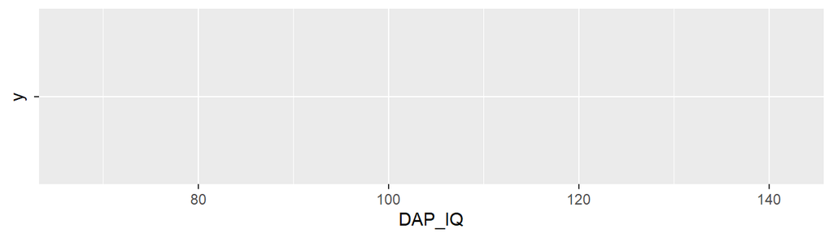

```r
DATA %>%
  ggplot(aes(x = DAP_IQ, y = ""))
```

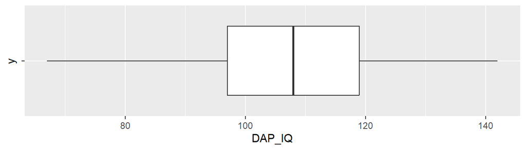

```r
DATA %>%
  ggplot(aes(x = DAP_IQ, y = "")) +
  geom_boxplot()
```

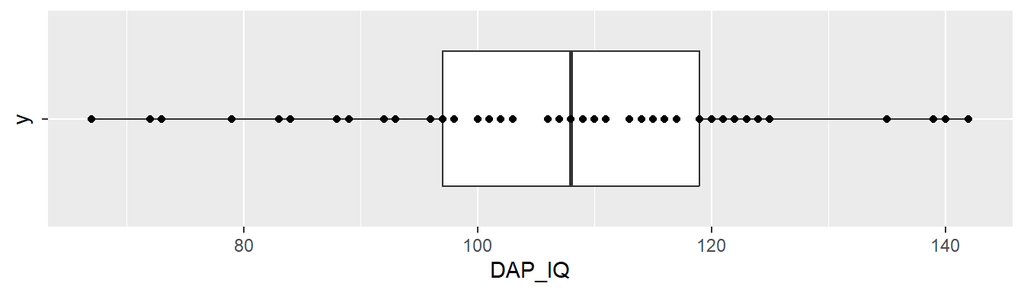

```r
DATA %>%
  ggplot(aes(x = DAP_IQ, y = "")) +
  geom_boxplot() +
  geom_point()
```

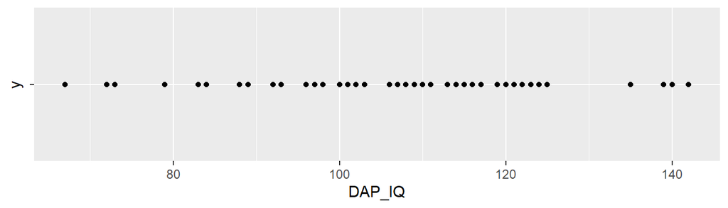

```r
DATA %>%
  ggplot(aes(x = DAP_IQ, y = "")) +
  geom_point()
```

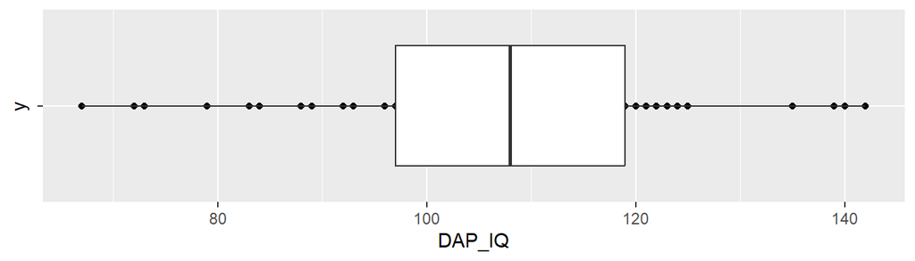

```r
DATA %>%
  ggplot(aes(x = DAP_IQ, y = "")) +
  geom_point() +
  geom_boxplot()
```

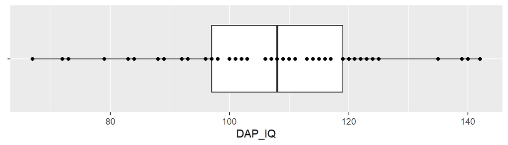

```r
DATA %>%
  ggplot(aes(x = DAP_IQ, y = "")) +
  geom_boxplot() +
  geom_point() +
  ylab(NULL)
```

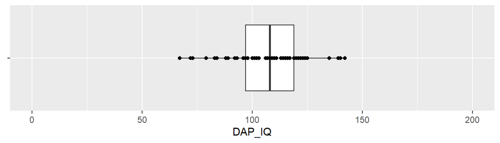

```r
DATA %>%
  ggplot(aes(x = DAP_IQ, y = "")) +
  geom_boxplot() +
  geom_point() +
  ylab(NULL) +
  xlim(c(0,200))
```

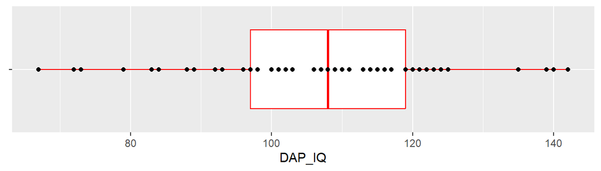

```r
DATA %>%
  ggplot(aes(x = DAP_IQ, y = "")) +
  geom_boxplot(color = "red") +
  geom_point() +
  ylab(NULL)
```

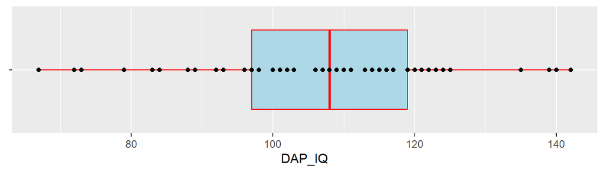

```r
DATA %>%
  ggplot(aes(x = DAP_IQ, y = "")) +
  geom_boxplot(color = "red", fill = "lightblue") +
  geom_point() +
  ylab(NULL)
```